# Track simulation

Juan S. Vargas Soto

```r
library(tidyverse)
```

The goal is to generate simulated tracks for individuals that do not move independently from each other, but rather have correlated movement. The most straightforward way to do this (at least conceptually) is to have individuals be attracted to each other, or avoid each other. This would generate temporal correlation that is not driven by spatial environmental factors. Nonetheless, some specific cells would have significant correlations. There are multiple alternatives to generate the tracks for the collapse paper. Ideally, I need a common framework that can generate independent tracks (this is the simplest), but also temporally correlated tracks. For example, individuals moving together (high positive correlation at all lags), or temporal avoidance (negative correlation at short lags). Perhaps the best option comes from Scharf’s paper [@Scharf2018], which has a model for joint movement using process convolution chains to account for covariance. Other options include: * Haydon et al. 2008, a two-state CRW that classified whether animals were in a group or not (https://doi.org/10.1098/rspb.2007.1688) * Langrock et al. 2013, MC model with a centre for the group but individualized behavior w.r.t. the centre (https://doi.org/10.1111/2041-210X.12155). Supposedly better than a mixture of CRW in simulating non-diffusive behavior. * Russell et al. 2015, include a marginal movement model using point process. Flexible, can incorporate marginal movement behavior and interactions separately (https://doi.org/10.1007/s13253-015-0219-0) * Scharf et al. 2016. Same authors, killer whale example. The model is hierarchical, with an underlying social component. (https://doi.org/10.1214/16-AOAS970). This paper is following up this approach.

# Process model

The process of movement is given by

$$\begin{aligned}
\tau &\equiv (\tau_1=0, \tau_2, ..., \tau_{m-1}, \tau_m=1)'\\
\Delta\tau_k &\equiv\tau_k-\tau_{k-1}, 1<k\le m \\
dB_i(\tau_k)&\sim\left\lbrace
\begin{array}
\mathcal{N}(0,\sigma^2_0); k=0\\
\mathcal{N}(0,\Delta\tau_k); k>0
\end{array}
\right.\\
dB_i&=(dB_i(\tau_1),...,dBi(\tau_m))'\\
dB &=(dB_1',...,dB_p')\\
\tilde{\mu}&=H^{inl}H^{soc}H^{bm}dB=\tilde{H}dB
\end{aligned}$$
$\tau$ are the discrete time steps (from 0 to 1),$\Delta\tau_k$ is the interval between them, $dB_i(\tau_k)$ is the Gaussian process difference between the positions, with a standard deviation proportional to the time interval. These are then processed with the brownian motion, social, and inertial convolution kernels to obtain the true position $\tilde\mu$.

## Gaussian process and Brownian motion

So first we get a set of positions. The position given Brownian motion is just the cumulative sum of deviations. The example below is in one dimension only to start.

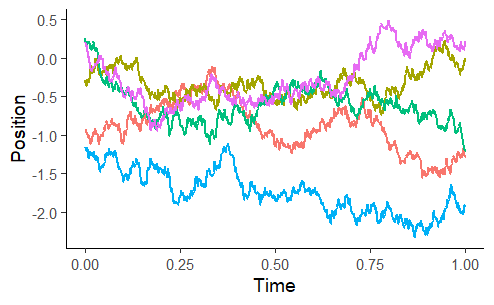

```r
# Fixed parameters
nind <- 5 # number of individuals
phi <- 0.04 # 0.04/3 for high tortuosity
sigma0 <- 1 # IG(1e-3, 1e-3)
sigmas <- 0.0125
sigmau <- 10
nsteps <- 24*60 # two months, hourly positions

tau <- seq(0, 1, length.out = nsteps) # time vector from 0 to 1
dtau <- diff(tau) # for regular interval this value will be constant

# create array of Gaussian base process
dB <- matrix(nrow = nsteps, ncol = nind)

# First positions come from a Normal dist with mean 0 and sd the fixed parameter sigma0. The remaining values of the Gaussian process are a function of the time interval.
set.seed(3)
dB[1,] <- rnorm(n = nind, mean = 0, sd = sqrt(sigma0))
dB[2:length(tau),] <- rnorm(n = nind*length(dtau), mean = 0,sd = sqrt(dtau))

# First kernel is Brownian motion, with convolution kernel h_bm = 1{tau<t}1{i=j}. This is simply the cumulative sum of noise
h_bm <- diag(nrow = nsteps)
h_bm[lower.tri(h_bm)] <- 1
mu_BM <- h_bm%*%dB

# Plot the trajectories
pdat_bm <- as_tibble(mu_BM) %>% mutate(time = tau, stage = "BM")
pdat_bm %>%
  pivot_longer(cols = 1:5, names_to = "ind") %>%
  ggplot(aes(time, value))+geom_path(aes(color = ind), size = 1, show.legend = F)+
  theme_classic(base_size = 14)+
  labs(x = "Time", y = "Position", color = "Individual")
```

## Social smoothing

Once we have the Brownian motion, we apply a social filter. The social smoothing kernel proposed in the paper is
$$h_{ij}^{(soc)}\equiv1_{\{\tau=\tau_{soc}\}}\frac{w_{ij}(\tau_{soc})}{|w_i.(\tau_{soc})|}\\
|w_i.(\tau_{soc})|\equiv\sum_{j=1}^pw_{ij}(\tau_{soc})$$
The position is obtained as:

$$\mu_1^{(soc)}(\tau_{soc})\equiv\sum_{j=1}^p\int_\mathcal{T}
h_{ij}^{(soc)}(\tau_{soc},\tau)\mu_j(\tau)d\tau$$

Simply, the x or y position is the weighted average of the positions of the individual and the other individuals, with the weights the social network edge values at that moment.

```r
# Social network edge strengths. This can be time dependent, e.g. a list of length nsteps where each element is a matrix of edge weights
create_soc_net <- function(n) {
  A <- matrix(runif(n*n), nrow = n)
  A <- A*upper.tri(A)+t(A*upper.tri(A)) #make symmetric
  diag(A) <- 1 # set diagonal to 1
  A
}
# w <- lapply(tau, \(x) create_soc_net(5)) # this is if you want a randomly changing matrix
# I could also have a stable matrix, where some individuals are associated but other aren't
A <- matrix(runif(nind*nind), nrow = nind)*rbinom(nind*nind, size = 1, prob = 0.2)
A <- A*upper.tri(A)+t(A*upper.tri(A)) #make symmetric
diag(A) <- 1 # set diagonal to 1
w <- replicate(n = nsteps,expr = A, simplify = FALSE) # this for a constant weight matrix

# convolution kernel hij(tau) is the weights matrix, divided by the row sums
h_soc <- lapply(w, \(x) x/rowSums(x))
# create an empty array with the same dimensions as mu_BM
mu_soc <- matrix(nrow = nsteps, ncol = nind)
# fill the array using dot product of the step*ind x and y matrices, multiplied by the rows of h_soc
for (t in 1:nsteps) {
    mu_soc[t,] <- h_soc[[t]]%*%mu_BM[t,]
}

pdat_soc <- as_tibble(mu_soc) %>% mutate(time = tau, stage = "Social")
```

## Inertial smoothing

There are multiple methods to make a broken-up Brownian motion path smoother. The one in the paper is

$$h_{ij}^{(inl)}(t,\tau)\equiv\frac{|t-\tau|}{\phi_{inl}}K_1(|t-\tau|/\phi_{inl})1_{\{i=j\}}$$

This is essentially a Gaussian filter that smooths the path and makes it differentiable, where $K_1$ is a modified Bessel function with parameter $\nu=1$. These are the weights that you multiply each position by. Below is an example with two individuals

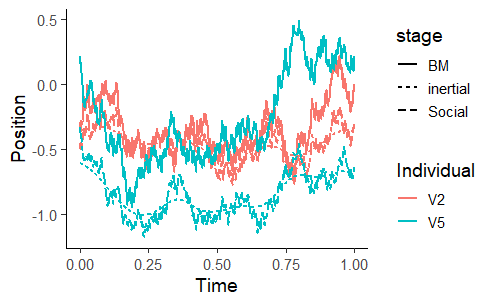

```r
# Inertial smoothing kernel
# The process here is just smoothing to better simulate real movement. The smoothing is done through a Bessel function
# mu_inl <- array(dim = dim(mu_BM), dimnames = dimnames(mu_BM))
h_inl <- outer(tau,tau, \(x,y) abs(x-y)/phi*besselK(abs(x-y)/phi, nu = 1))
diag(h_inl) <- 1
h_inl <- h_inl/rowSums(h_inl) # this is the only way I found to make it work, have mu_inl be a weighted average, where the weights are the values in the h_inl matrix
mu_inl <- h_inl%*%mu_soc

# Plot
pdat_inl <- as_tibble(mu_inl) %>% mutate(time = tau, stage = "inertial")

rbind(pdat_bm, pdat_soc, pdat_inl) %>%
  pivot_longer(cols = 1:5, names_to = "Individual") %>%
  filter(Individual %in% c("V2","V5")) %>%
  ggplot(aes(time, value))+geom_path(aes(color = Individual, linetype = stage), size = 1)+
  theme_classic(base_size = 14)+
  labs(x = "Time", y = "Position", color = "Individual")
```

## Data model

Finally, based on the real position, the data model is obtained as a random variable.
$$\begin{align}
s&\sim
\mathcal{N}(0,\sigma^2_s(\mathbf{I}+\sigma^2_{\mu/s}\Delta\tau\mathbf{\tilde{H}}\Sigma_{dB}\mathbf{\tilde{H}}'
))\\
\mathbf{\tilde{H}}&=\mathbf{H}^{(inl)}(\phi_{inl})\mathbf{H^{(soc)}}(d\mathbf{B}_w,\phi_w,\sigma^2_w)\mathbf{H}^{(bm)}\\
\Sigma_{dB}(t, \tau, i,
j)&=\mathbf{1}_{\{t=\tau\}}(\sigma^2\mathbf{1}_{\{t=0\}}+\mathbf{1}_{\{t>0\}})\mathbf{1}_{\{i=j\}}
\end{align}$$
In practice this comes down to adding a measurement error to the true position:
$$s_i(t)\equiv\sigma_\mu\tilde\mu_i(t)+\varepsilon_i(t),$$
where the the error is normally distributed, with mean 0 and variance $\sigma_s^2$.

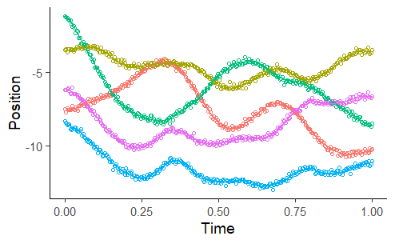